# Real Time FXCM

[figure not shown]

## 1. Intraday Data Collection

- **FXCM Weekly Ticked Data** : You can get the tick data via FXCMTickData `All timestamps are in UTC`.
- **Historical Data Downloader Basic** : you can get the historical price via [Historical Spreads](https://www.fxcm.com/uk/why-fxcm/execution/historical-spreads/)

Besides, you can use my Web Application [**DataCollection**](https://beta.rstudioconnect.com/content/3153/) for high frequency algorithmic trading backtesting.

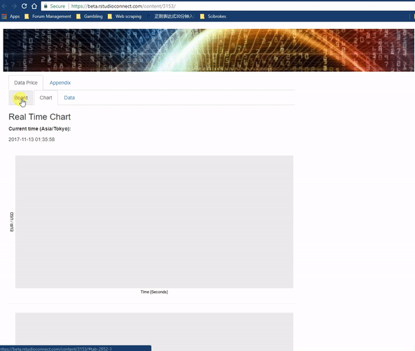

## 2. High Frequency Algorithmic Trading

[figure not shown]

## 3. Reference

1. [binary.com : Job Application - Quantitative Analyst](https://github.com/englianhu/binary.com-interview-question) ❤️‍🔥
2. [如何用R语言开始量化投资](https://github.com/scibrokes/real-time-fxcm/blob/master/reference/%E5%A6%82%E4%BD%95%E7%94%A8R%E8%AF%AD%E8%A8%80%E5%BC%80%E5%A7%8B%E9%87%8F%E5%8C%96%E6%8A%95%E8%B5%84.pdf)
3. 解密复兴科技 - 基于隐蔽马尔科夫模型的时序分析方法 ❤️‍🔥
4. [原则 - 雷·达里奥](https://github.com/scibrokes/analyse-the-finance-and-stocks-price-of-bookmakers/blob/master/reference/%E5%8E%9F%E5%88%99%20-%20%E9%9B%B7%C2%B7%E8%BE%BE%E9%87%8C%E5%A5%A5.pdf)
5. [Successful Algorithmic Trading](https://github.com/englianhu/binary.com-interview-question/blob/master/reference/Successful%20Algorithmic%20Trading.pdf)
6. [量化交易学习-订单簿建模](https://zhuanlan.zhihu.com/p/499342831)
7. [哪种量化策略在国内最有前途？](https://www.zhihu.com/question/68030592/answer/2239306330)
8. [知呼：量化交易的频谱分析与策略搭配规律](https://zhuanlan.zhihu.com/p/89404944) ❤️‍🔥
9. [知呼：量化投资方面，国内外都有哪些好的论坛或者网站？](https://www.zhihu.com/question/20874888/answer/61854182) ❤️‍🔥
10. [韦纳软件 VeighNa](https://www.vnpy.com) ❤️‍🔥
11. [GitHub : VeighNa - By Traders, For Traders.](https://github.com/vnpy/vnpy) ❤️‍🔥
12. [知乎：最新33家国内百亿量化私募 Hedge Fund 核心人员背景简析（含千亿级）20220226](https://zhuanlan.zhihu.com/p/288461500)
13. [知乎：中国量化私募：竞争全球，背水一战！](https://zhuanlan.zhihu.com/p/145113688)
14. [GitHub : Tushare](https://github.com/waditu/tushare)
15. [Tushare Pro版](https://tushare.pro)
16. [Tushare](http://tushare.org)
17. [中国期货市场量化交易(R与C++版) - 相关推荐](https://ebook365.org/B07MVZ4XP7)
18. [金工量化优质书单推荐及下载](https://www.cxybb.com/article/m0_37639589/90765551)
19. [近十年量化交易领域最重要的十本参考书是哪些？](https://www.zhihu.com/question/23857983)
20. [知乎：量化一般用什么软件比较好，在哪里下载，还有一般量化的平台都有哪些呀？](https://www.zhihu.com/question/62413612)
21. [知乎：量化投资学习推荐的书籍都有哪些？](https://www.zhihu.com/question/54727745)